# In-Class Session 7: LATE, Judges, Shift-Share, and Weak Instruments

Econometrics I

This notebook reproduces the simulations behind Lecture 7 (the slides use `iv2_sims.R`) and leaves you three problems. Only `fixest` is needed.

# Part 1: LATE in an encouragement design

A retailer emails a random half of its customers to nudge them onto its app. Twenty percent would install it anyway (always-takers), forty percent install it only if emailed (compliers), forty percent never do. The app’s effect on spending differs by type.

```r
sim_late <- function(N = 10000, tau = c(always = 2.0, complier = 0.8, never = 0.5)) {
  type <- sample(names(tau), N, replace = TRUE, prob = c(0.2, 0.4, 0.4))
  Z <- rbinom(N, 1, 0.5)
  D <- as.integer(type == "always" | (type == "complier" & Z == 1))
  base <- c(always = 3, complier = 1, never = 0.5)[type]
  tenure <- c(always = 4, complier = 2, never = 1)[type] + rnorm(N)
  data.frame(y = base + tau[type] * D + rnorm(N), D, Z, tenure, type, tau = tau[type])
}
d <- sim_late()
etable(feols(y ~ D, d), feols(y ~ Z, d), feols(D ~ Z, d), feols(y ~ 1 | D ~ Z, d),
       headers = c("OLS", "reduced form", "first stage", "2SLS"))
```

```
##                    feols(y ~ D, d)    feols(y ~ Z, d)    feols(D ~ Z, d)
##                                OLS       reduced form        first stage
## Dependent Var.:                  y                  y                  D
##
## Constant        0.6841*** (0.0186)  1.621*** (0.0276) 0.2049*** (0.0064)
## D                2.698*** (0.0295)
## Z                                  0.2604*** (0.0390) 0.3809*** (0.0090)
## _______________ __________________ __________________ __________________
## S.E. type                      IID                IID                IID
## Observations                10,000             10,000             10,000
## R2                         0.45561            0.00444            0.15173
## Adj. R2                    0.45556            0.00434            0.15165
##
##                 feols(y ~ 1 | D ..
##                               2SLS
## Dependent Var.:                  y
##
## Constant         1.481*** (0.0403)
## D               0.6836*** (0.0917)
## Z
## _______________ __________________
## S.E. type                      IID
## Observations                10,000
## R2                         0.00444
## Adj. R2                    0.00434
## ---
## Signif. codes: 0 '***' 0.001 '**' 0.01 '*' 0.05 '.' 0.1 ' ' 1
```

```r
c(LATE = mean(d$tau[d$type == "complier"]), ATE = mean(d$tau), ATT = mean(d$tau[d$D == 1]))
```

```
##     LATE      ATE      ATT
## 0.800000 0.916400 1.401062
```

Who are the compliers? Abadie’s trick: apply the Wald ratio to $X \cdot D$ instead of $y$.

```r
with(d, (mean(tenure[Z == 1] * D[Z == 1]) - mean(tenure[Z == 0] * D[Z == 0])) / (mean(D[Z == 1]) - mean(D[Z == 0])))
```

```
## [1] 1.91529
```

```r
tapply(d$tenure, d$type, mean)    # the truth, which you never see in real data
```

```
##   always complier    never
## 4.014082 2.003274 1.011045
```

# In-class problem 1: which rows move?

Re-simulate with the complier effect doubled (`tau = c(always = 2, complier = 1.6, never = 0.5)`), then with the always-taker effect doubled instead. For each, say which of the four regression rows change and which of the three truths (LATE, ATE, ATT) change, and why 2SLS never notices the always-takers.

```r
# your code here
```

# Part 2: A judge design with refund agents

Requests are routed at random to 50 agents who differ in generosity. The claim’s merit $q$ is seen by the agent, not by us; refunds build the most goodwill for weak claims.

```r
sim_refund <- function(N = 20000, J = 50, typed = FALSE) {
  q <- rnorm(N); agent <- sample(1:J, N, replace = TRUE)
  ctype <- sample(c("shipping", "damage"), N, replace = TRUE)
  gen <- rnorm(J, -0.5, 0.5)
  if (typed) { gen2 <- -0.5 - (gen + 0.5)                # agents lenient on shipping are strict on damage
    cutoff <- ifelse(ctype == "shipping", gen[agent], gen2[agent]) } else cutoff <- gen[agent]
  R <- as.integer(q + cutoff + rnorm(N, 0, 0.5) > 0)   # 'cutoff' is generosity: higher = more lenient
  tau <- 20 - 15 * q
  d <- data.frame(spend = 100 + tau * R + 30 * q + rnorm(N, 0, 20), R, agent, q, tau, ctype)
  tot <- tapply(R, agent, sum); n_j <- tapply(R, agent, length)
  d$len <- (tot[agent] - R) / (n_j[agent] - 1)           # leave-one-out leniency
  d
}
dr <- sim_refund()
etable(feols(spend ~ R, dr, cluster = ~agent), feols(R ~ len, dr, cluster = ~agent),
       feols(spend ~ 1 | R ~ len, dr, cluster = ~agent), headers = c("OLS", "first stage", "2SLS"))
```

```
##                 feols(spend ~ R.. feols(R ~ len, d.. feols(spend ~ 1..
##                               OLS        first stage              2SLS
## Dependent Var.:             spend                  R             spend
##
## Constant        86.00*** (0.8880) 0.0072*** (0.0014) 97.69*** (0.6146)
## R               46.73*** (0.5700)                     14.14*** (1.751)
## len                               0.9798*** (0.0038)
## _______________ _________________ __________________ _________________
## S.E.: Clustered         by: agent          by: agent         by: agent
## Observations               20,000             20,000            20,000
## R2                        0.38173            0.10631           0.00371
## Adj. R2                   0.38170            0.10627           0.00366
## ---
## Signif. codes: 0 '***' 0.001 '**' 0.01 '*' 0.05 '.' 0.1 ' ' 1
```

```r
c(ATE = mean(dr$tau), effect_on_refunded = mean(dr$tau[dr$R == 1]))
```

```
##                ATE effect_on_refunded
##           20.10154            7.54103
```

The first-stage picture, and the monotonicity check by claim type:

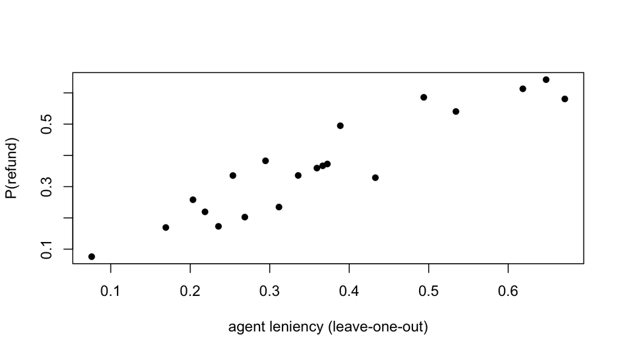

```r
bins <- cut(dr$len, quantile(dr$len, seq(0, 1, .05)), include.lowest = TRUE)
plot(tapply(dr$len, bins, mean), tapply(dr$R, bins, mean), pch = 16, xlab = "agent leniency (leave-one-out)", ylab = "P(refund)")
```

```r
sapply(split(dr, dr$ctype), function(s) coef(feols(R ~ len, s))[2])
```

```
##   damage.len shipping.len
##    1.0085453    0.9521879
```

# In-class problem 2: agents with tastes

Re-simulate with `typed = TRUE`: agents who are lenient on shipping claims are strict on damage claims, and vice versa.

1. Re-run the overall first stage and the first stage by claim type. What do you see?
2. Re-run 2SLS with the pooled leniency measure. Is it still a LATE for anyone?
3. Fix it: compute leniency *within* claim type (each agent’s leave-one-out rate on shipping claims, separately from damage claims) and re-estimate. Explain in two sentences what assumption the fix restores.

```r
# your code here
```

# Part 3: Shift-share with Rotemberg weights

Markets differ in which sector their banks lend to; national sector credit shocks move local credit growth; the question is the effect of local credit on firm entry (truth 0.4).

```r
sim_ss <- function(M = 1000, K = 6) {
  dom <- sample(1:K, M, replace = TRUE); sh <- matrix(0.4 / (K - 1), M, K); sh[cbind(1:M, dom)] <- 0.6
  g <- rnorm(K); eta <- rnorm(M); B <- as.vector(sh %*% g)
  x <- B + 0.5 * eta + rnorm(M, 0, 0.3); y <- 0.4 * x + eta + rnorm(M, 0, 0.3)
  list(d = data.frame(y, x, B), sh = sh, g = g)
}
s <- sim_ss(); d <- s$d
etable(feols(y ~ x, d), feols(y ~ 1 | x ~ B, d, vcov = "hetero"), headers = c("OLS", "2SLS"))
```

```
##                     feols(y ~ x, d) feols(y ~ 1 | x ..
##                                 OLS               2SLS
## Dependent Var.:                   y                  y
##
## Constant        -0.1129*** (0.0283)    0.0019 (0.0331)
## x                0.9722*** (0.0297) 0.3949*** (0.0462)
## _______________ ___________________ __________________
## S.E. type                       IID Heteroskedas.-rob.
## Observations                  1,000              1,000
## R2                          0.51785            0.05065
## Adj. R2                     0.51736            0.04970
## ---
## Signif. codes: 0 '***' 0.001 '**' 0.01 '*' 0.05 '.' 0.1 ' ' 1
```

```r
# Rotemberg weights: alpha_k proportional to g_k * sum_m s_mk * (x_m - mean x)
xt <- d$x - mean(d$x)
alpha <- sapply(1:6, function(k) s$g[k] * sum(s$sh[, k] * xt)); alpha <- alpha / sum(alpha)
beta_k <- sapply(1:6, function(k) unname(coef(feols(y ~ 1 | x ~ z, data.frame(d, z = s$sh[, k] * s$g[k])))[2]))
round(cbind(sector = 1:6, shock = s$g, weight = alpha, beta_k = beta_k), 2); sum(alpha * beta_k)
```

```
##      sector shock weight beta_k
## [1,]      1 -0.90   0.10   0.43
## [2,]      2  2.12   0.34   0.32
## [3,]      3 -0.06   0.00   0.72
## [4,]      4 -0.79   0.06   0.31
## [5,]      5 -1.32   0.16   0.38
## [6,]      6  2.00   0.33   0.48
```

```
## [1] 0.3948588
```

# In-class problem 3: drop the sector that carries the estimate

Remove the sector with the largest Rotemberg weight (set its shock to zero, or drop it from the instrument) and re-estimate.

1. What happens to the 2SLS estimate and to the first-stage $F$?
2. If that sector’s share-exogeneity claim were the doubtful one, what would you conclude from the comparison?
3. Bonus: Anderson-Rubin. For a grid of $\beta_0$ from 0 to 1, regress $y - \beta_0 x$ on $B$ and record whether the coefficient is significant at 5%. Report the set of $\beta_0$ not rejected and compare it to the 2SLS confidence interval.

```r
# your code here
```